# Module 4 - Multiple Linear Regression

## Data and Description

*Note: you will be duplicating a lot of code from Module 2 - it will save you time if you open up your Module 2 code and copy/paste as needed. Alternatively, you can skip the sections that have you copy/paste code from Module 2 to save time. Also, we won’t worry about the axis limits for this coding day to save time.*

**This is the same data set used in the Module 4 Course Notes. You can check your code output against the output from the course notes to verify you are getting the correct results.**

Companies are continually evaluating supervisors to not only determine adequate performance, but also gauge employee morale (an important indicator for employee productivity). In an effort to understand the important aspects of a good supervisor, 30 employees at a certain company were asked to provide an overall rating and scores on 6 characteristics of their immediate managers. Employees were asked to rate the following statements on a scale from 0 to 100 (0 meaning ”completely disagree” to 100 meaning ”completely agree”):

| Variable | Description |
| --- | --- |
| Rating | Overall rating of supervisor performance. Higher score means better supervisor. |
| Complaints | Score for “Your supervisor handles employee complaints appropriately.” |
| Privileges | Score for “Your supervisor allows special privileges.” |
| Learn | Score for “Your supervisor provides opportunities to learn new things.” |
| Raises | Score for “Your supervisor bases raises on performance.” |
| Critical | Score for “Your supervisor is too critical of poor performance.” |
| Advance | Score for “I am *not* satisfied with the rate I am advancing in the company.” |

Do the following:

1. Download the “Supervisor.txt” file from Canvas and put it in the same folder as this R Markdown file.
2. Read in the data set, call it “super”, and take a look at the top few rows.

```r
#super <- read.csv("Supervisor.txt", header = TRUE, sep = " ")
#head(super)

(super <- read_table2("Supervisor.txt"))
```

```
## # A tibble: 30 x 7
##    Rating Complaints Privileges Learn Raises Critical Advance
##     <dbl>      <dbl>      <dbl> <dbl>  <dbl>    <dbl>   <dbl>
##  1     43         51         30    39     61       92      45
##  2     63         64         51    54     63       73      47
##  3     71         70         68    69     76       86      48
##  4     61         63         45    47     54       84      35
##  5     81         78         56    66     71       83      47
##  6     43         55         49    44     54       49      34
##  7     58         67         42    56     66       68      35
##  8     71         75         50    55     70       66      41
##  9     72         82         72    67     71       83      31
## 10     67         61         45    47     62       80      41
## # … with 20 more rows
```

## Explore the Data

### Create a Scatterplot Matrix. Do you observe any variables that appear strongly linearly correlated?

Hint: you can use the `plot` function or the `pairs` function.

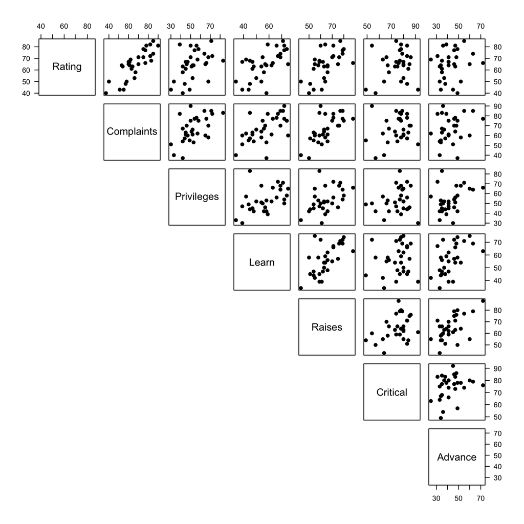

```r
point_matrix <- function(data) {
  par(pty = "s", las = 1)
  pairs(data, pch = 19, lower.panel = NULL)
}
point_matrix(super)
```

### Create a Correlation Matrix. Do the correlations here match your insights obtained from the scatterplot matrix?

Hint: use the `cor` function. You may want to use the `round` function to display only 2 decimal places for easier viewing. Hint: for a color- and shape-coded correlation matrix, use the `corrplot` package and function (use the `cor` function as input).

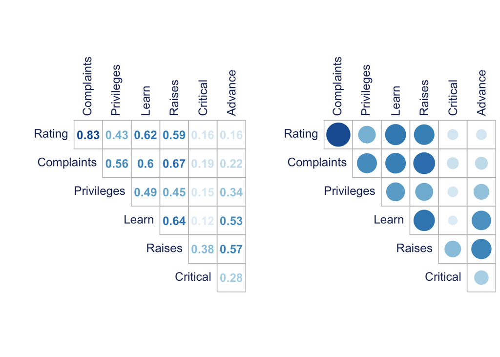

```r
show_cor <- function(data) {
  par(mfrow = c(1, 2))
  corrplot(cor(data), method = "number", type = "upper", diag = F, tl.col = "#1f3366", cl.pos = "n")
  corrplot(cor(data), type = "upper", diag = F, tl.col = "#1f3366", cl.pos = "n")
}
show_cor(super)
```

## Fit a Multiple Linear Regression Model

Make sure to save the residuals to your `super` data frame.

Hint: for the X variables in the `lm` function, you can type all the variables out separated by a plus sign “+”, or you can simply type “~.”. The “.” tells R that you want to include every column in your data set, except the column you specified as the response, as an independent variable in your model. You have to be careful with the “~.” notation. Once you save the residuals and/or fitted values to the data frame (or anything else), you cannot rerun your linear model, otherwise those to variables will be added to the model. Your output should match the output in the class notes.

```r
super_lm <- lm(Rating ~ ., data = super)
summary(super_lm)
```

```
##
## Call:
## lm(formula = Rating ~ ., data = super)
##
## Residuals:
##      Min       1Q   Median       3Q      Max
## -10.9418  -4.3555   0.3158   5.5425  11.5990
##
## Coefficients:
##             Estimate Std. Error t value Pr(>|t|)
## (Intercept) 10.78708   11.58926   0.931 0.361634
## Complaints   0.61319    0.16098   3.809 0.000903 ***
## Privileges  -0.07305    0.13572  -0.538 0.595594
## Learn        0.32033    0.16852   1.901 0.069925 .
## Raises       0.08173    0.22148   0.369 0.715480
## Critical     0.03838    0.14700   0.261 0.796334
## Advance     -0.21706    0.17821  -1.218 0.235577
## ---
## Signif. codes:  0 '***' 0.001 '**' 0.01 '*' 0.05 '.' 0.1 ' ' 1
##
## Residual standard error: 7.068 on 23 degrees of freedom
## Multiple R-squared:  0.7326, Adjusted R-squared:  0.6628
## F-statistic:  10.5 on 6 and 23 DF,  p-value: 1.24e-05
```

## Check Multiple Linear Regression Model Assumptions

### 1. The X’s vs Y are linear

Check your scatterplot matrix from above, in addition to the residuals vs. fitted values plot, the residuals vs predictor plots, and the partial regression plots (below).

**(a) Scatterplot Matrix (already created - see above)**

**(b) Residuals vs. Fitted Values Plot**

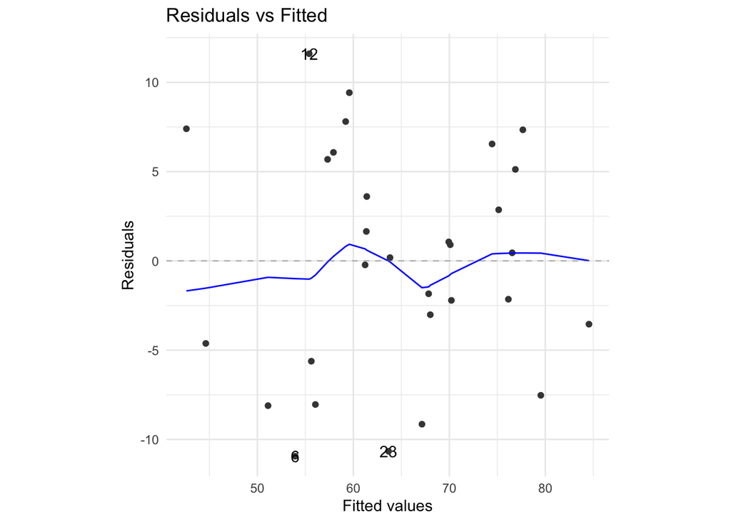

```r
resid_vs_fitted <- function(model) {
  autoplot(model, which = 1, ncol = 1) +
    theme_minimal() +
    theme(aspect.ratio = 1)
}
resid_vs_fitted(super_lm)
```

**(c) Residuals vs. Predictor Plots (6 plots in total)**

[figure not shown]

```r
resid_vs_pred <- function(model) {
  data <- model.frame(model)
  predictors <- attr(model$terms, "term.labels")
  residuals <- resid(super_lm)
  plots <- list()
  for (i in predictors) {
    plots[[i]] <- ggplot(data = data,
                         mapping = aes(x = pull(data, i),
                                       y = model$residuals)) +
      geom_point() +
      theme_minimal() +
      theme(aspect.ratio = 1) +
      xlab(i) +
      ylab("Residuals")
    plots[[i]]
  }
  plots["ncol"] <- ceiling(sqrt(length(plots)))
  do.call(grid.arrange, plots)
}
resid_vs_pred(super_lm)
```

**(d) Partial Regression Plots (also called “Added Variable” plots)**

Hint: use the `avPlots` function with your fitted model as the argument to the function.

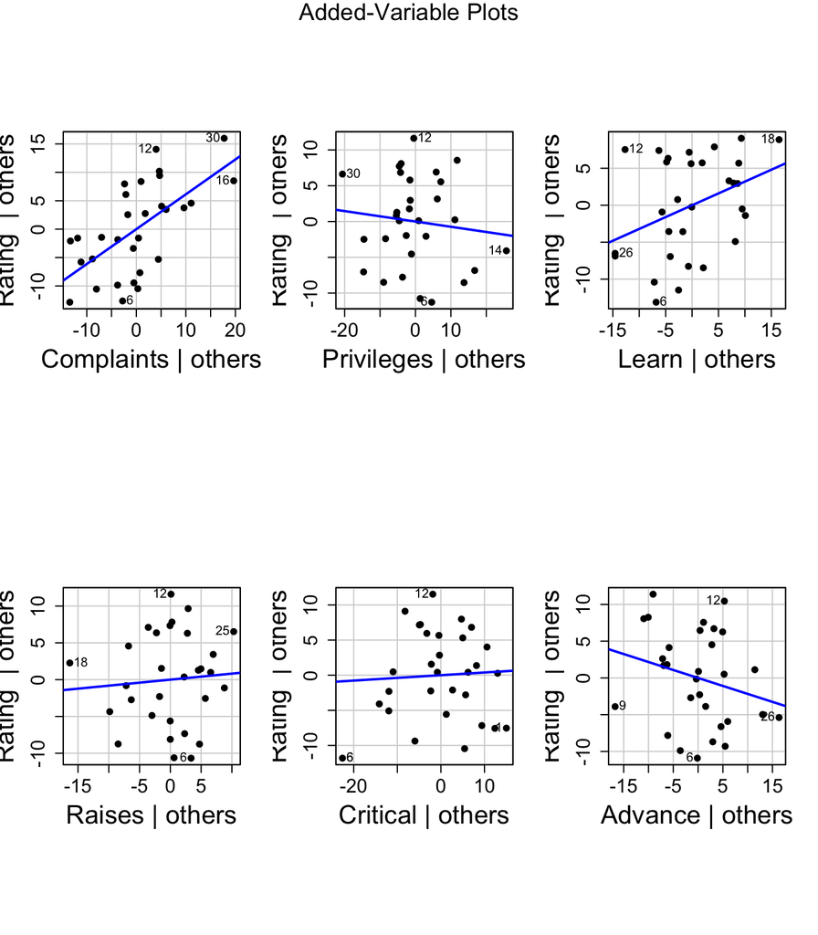

```r
added_variable_plots <- function(model) {
  predictors <- attr(model$terms, "term.labels")
  rows <- floor(sqrt(length(predictors)))
  cols <- length(predictors) / rows
  par(pty = "s", cex.lab = 2, cex.axis = 1.5)
  avPlots(model, layout = c(rows, cols), pch = 19)
}
added_variable_plots(super_lm)
```